# **Kaggle M5 Forecasting - Accuracy**

## **5. Feature Importance**

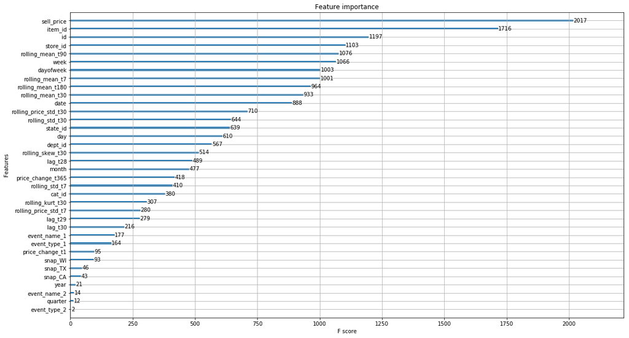

```python
# plot feature importance
plot_importance(xgb_tg_encode)

# change the size of the the plot
fig = plt.gcf()
fig.set_size_inches(18.5, 10.5)
```

- Feature about price: `sell_price`
- Feature about categorical id: `item_id`, `id`, `store_id`
- Feature about historical demand: `rolling_mean_t7/t30/t90/t180`
- Feature about time: `week`, `dayofweek`, `date`

## **6. Shapley Value**

In the following section, we use XGBoost's `predict()` function returns Shapley values for each row of the test set. Compared to traditional single-value feature importance measures, local Shapley values for each input will be ploted below to get a more holistic and consisent measurement for the global importance of each input variable.

```python
# prepare small sample of validation set which contains 28 days
# otherwise it will suffer memory error
small_val = data[(data['date'] > 20160424) & (data['date'] <= 20160522)]
y_sval = small_val['demand']
del small_val['demand']
```

```python
def spv(x_val, y_val):
    # convert validation to DMatrix `dval` again
    dval = xgb.DMatrix(x_val, y_val)

    # shap_values is Numpy array
    shap_values = xgb_tg_encode.predict(dval, pred_contribs=True, ntree_limit=xgb_tg_encode.best_ntree_limit)

    # plot Shapley variable importance summary
    shap.summary_plot(shap_values[:, :-1], validation[xgb_tg_encode.feature_names])
```

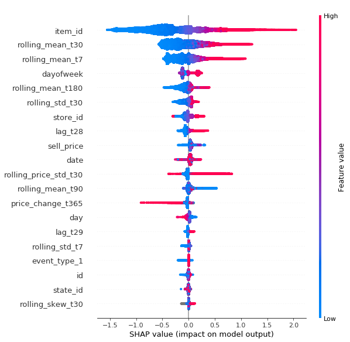

```python
# obtain the shapley variable importance summary
spv(small_val, y_sval)
```

We analyze Shapley Value plot from three aspects:  
**Range**  
X-axis Shapley value indicates different level of impact for each value in the specified featrue. In general, the impact ranges from negative to positive for each feature, but their range vary a lot. Top 3 features have the most largest range. `item_id` is the most important feature ranging approximately from -1.5 to 2.0, while 2nd `rolling_mean_t30` and 3rd `rolling_mean_t7` range approximately from -0.5 to 1.  
**Color**  
The color distribution of top 3 features are all blue in left and red in right, meaning that small numerical value in that column has small Shapley Value, while high value will have positive Shapley Value. Recap that `item_id` is target-encoded feature which targets at `demand`. So the color of top 3 features is telling us lower historical sales has negative impact on the value of sales prediction, while higher historial sales increase the value of sales prediction.  
**Rank**  
We also summerize top 10 features according to Shapley Value:

- Feature about categorical id: `item_id`, `store_id`
- Feature about historical demand: `rolling_mean_t7/t30/t180`, `rolling_std_t30`, `lag_t28`
- Feature about time: `dayofweek`, `date`
- Feature about price: `sell_price`

## **7. Calculating partial dependence and ICE**

This part of the notebook is also inspired by the work of Patrick Hall and the H20.ai team. We would like to use Partial Dependence (PD from now) and ICE to validate and explain monotonic behavior. We believe that Patrick did a wonderful job in explaning the role PD and ICE can play in making a machine learning model more transparent and explainable. The writing right below is heavily inspired by his team's work.

Partial dependence plots are used to view the global, average prediction behavior of a variable under the monotonic model as a function of specific values of an input variable of interest. PD plots indicate how the predictions change based on the values of the input variable of interest, while taking nonlinearity into consideration and averaging out the effects of all other input variables.

Individual conditional expectation (ICE) plots, a newer and less well-known adaptation of partial dependence plots, can be used to create more localized explanations for a single observation of data. ICE is also a type of nonlinear sensitivity analysis in which the model predictions for a single observation are measured while a feature of interest is varied over its domain (Hall and H20.ai team, 2017)

We can display PD and ICE plots on the same graph as they are measured on the same scale. The graph will help us compare the global, average prediction behavior for the entire model and the local prediction behavior for certain rows of data. ICE curves diverging from the PD curve can be indicative of strong interactions or correlation issues among predictors.

We will calculate PD and ICE, then present the plots for the 4 important features according to Shapley's values, which are `rolling_mean_t30`, `rolling_mean_t7`, `sell_price`, and `lag_t28`.

### **Function for PD calculation**

```python
def par_dep(xs, frame, model, resolution=20, bins=None):

    """ Creates Pandas DataFrame containing partial dependence for a
        single variable.

    Args:
        xs: Variable for which to calculate partial dependence.
        frame: Pandas DataFrame for which to calculate partial dependence.
        model: XGBoost model for which to calculate partial dependence.
        resolution: The number of points across the domain of xs for which
                    to calculate partial dependence, default 20.
        bins: List of values at which to set xs, default 20 equally-spaced
              points between column minimum and maximum.

    Returns:
        Pandas DataFrame containing partial dependence values.

    """

    # turn off pesky Pandas copy warning
    pd.options.mode.chained_assignment = None

    # initialize empty Pandas DataFrame with correct column names
    par_dep_frame = pd.DataFrame(columns=[xs, 'partial_dependence'])

    # cache original column values
    col_cache = frame.loc[:, xs].copy(deep=True)

    # determine values at which to calculate partial dependence
    if bins == None:
        min_ = frame[xs].min()
        max_ = frame[xs].max()
        by = (max_ - min_)/resolution
        bins = np.arange(min_, max_, by)

    # calculate partial dependence
    # by setting column of interest to constant
    # and scoring the altered data and taking the mean of the predictions
    for j in bins:
        frame.loc[:, xs] = j
        dframe = xgb.DMatrix(frame)
        par_dep_i = pd.DataFrame(model.predict(dframe, ntree_limit=model.best_ntree_limit))
        par_dep_j = par_dep_i.mean()[0]
        par_dep_frame = par_dep_frame.append({xs:j,
                                              'partial_dependence': par_dep_j},
                                              ignore_index=True)

    # return input frame to original cached state
    frame.loc[:, xs] = col_cache

    return par_dep_frame
```

### **Calculate Partial Dependence**

```python
#calculate PD for 'rolling_mean_t30' - moving average of demand in the last 30 days
par_dep_rm30 = par_dep('rolling_mean_t30', small_val, xgb_tg_encode, resolution=20)
```

```python
par_dep_rm30
```

|  | rolling_mean_t30 | partial_dependence |
| --- | --- | --- |
| 0 | 0.00000 | 1.067577 |
| 1 | 5.90625 | 1.823697 |
| 2 | 11.81250 | 2.175320 |
| 3 | 17.71875 | 2.470520 |
| 4 | 23.62500 | 2.920000 |
| 5 | 29.53125 | 3.131217 |
| 6 | 35.43750 | 3.590809 |
| 7 | 41.34375 | 3.525867 |
| 8 | 47.25000 | 3.607496 |
| 9 | 53.15625 | 3.716871 |
| 10 | 59.06250 | 3.744160 |
| 11 | 64.96875 | 3.744160 |
| 12 | 70.87500 | 3.744160 |
| 13 | 76.78125 | 3.744160 |
| 14 | 82.68750 | 3.744160 |
| 15 | 88.59375 | 3.744160 |
| 16 | 94.50000 | 3.744160 |
| 17 | 100.40625 | 3.744160 |
| 18 | 106.31250 | 3.744160 |
| 19 | 112.21875 | 3.744160 |

The partial dependence for `rolling_mean_t30` can be seen to increase as `rolling_mean_t30` increases. This finding is aligned with expectations that the model predictions of demand will be monotonically increasing with increasing moving average demand of the last month. In other words, if the items were popular last month, it is reasonable to expect the item to be popular this month.

```python
#calculate PD for 'rolling_mean_t7' - moving average of demand in the last 7 days
par_dep_rm7 = par_dep('rolling_mean_t7', small_val, xgb_tg_encode, resolution=20)
```

```python
par_dep_rm7
```

|  | rolling_mean_t7 | partial_dependence |
| --- | --- | --- |
| 0 | 0.0 | 1.058292 |
| 1 | 6.5 | 1.839689 |
| 2 | 13.0 | 2.184404 |
| 3 | 19.5 | 2.324385 |
| 4 | 26.0 | 2.547439 |
| 5 | 32.5 | 2.777301 |
| 6 | 39.0 | 2.777167 |
| 7 | 45.5 | 2.803275 |
| 8 | 52.0 | 3.223659 |
| 9 | 58.5 | 3.234867 |
| 10 | 65.0 | 3.296026 |
| 11 | 71.5 | 3.296026 |
| 12 | 78.0 | 3.296026 |
| 13 | 84.5 | 3.296026 |
| 14 | 91.0 | 3.296026 |
| 15 | 97.5 | 3.296026 |
| 16 | 104.0 | 3.296026 |
| 17 | 110.5 | 3.296026 |
| 18 | 117.0 | 3.296026 |
| 19 | 123.5 | 3.296026 |

The partial dependence for `rolling_mean_t7` can be seen to increase as `rolling_mean_t7` increases. This finding is aligned with expectations that the model predictions of demand will be monotonically increasing with increasing moving average demand of the last week.

Next, we will calculate PD for `sell_price` and `lag_t28`.

```python
par_dep_sell_price = par_dep('sell_price', small_val, xgb_tg_encode)
par_dep_lag_t28 = par_dep('lag_t28', small_val, xgb_tg_encode)
```

```python
par_dep_sell_price
```

|  | sell_price | partial_dependence |
| --- | --- | --- |
| 0 | 0.099976 | 0.804735 |
| 1 | 1.781226 | 1.313278 |
| 2 | 3.462476 | 1.295172 |
| 3 | 5.143726 | 1.304008 |
| 4 | 6.824976 | 1.313181 |
| 5 | 8.506226 | 1.329806 |
| 6 | 10.187476 | 1.233134 |
| 7 | 11.868726 | 1.233162 |
| 8 | 13.549976 | 1.235173 |
| 9 | 15.231226 | 1.235173 |
| 10 | 16.912476 | 1.235173 |
| 11 | 18.593726 | 1.235173 |
| 12 | 20.274976 | 1.235173 |
| 13 | 21.956226 | 1.235173 |
| 14 | 23.637476 | 1.235173 |
| 15 | 25.318726 | 1.235173 |
| 16 | 26.999976 | 1.235173 |
| 17 | 28.681226 | 1.235173 |
| 18 | 30.362476 | 1.235173 |
| 19 | 32.043726 | 1.235173 |

The partial dependence for `sell_price` does not monotonically change in either direction as `sell_price` increases. We expected that as sell price increases, PD will decrease. However, for items with low sell prices, predicted demand actually increases as sell prices increase. For items with mid-rang price, predicted demand will decrease as sell prices increase. For items with high sell prices, increasing sell prices will not affect the predicted demand or PD. The unchanging PD of higher price items can be explained by a smaller sample size of such item compared to low and mid-range priced items.

```python
par_dep_lag_t28
```

|  | lag_t28 | partial_dependence |
| --- | --- | --- |
| 0 | 0.0 | 1.227338 |
| 1 | 10.2 | 1.385203 |
| 2 | 20.4 | 1.499723 |
| 3 | 30.6 | 1.580217 |
| 4 | 40.8 | 1.598423 |
| 5 | 51.0 | 1.651298 |
| 6 | 61.2 | 1.669505 |
| 7 | 71.4 | 1.675065 |
| 8 | 81.6 | 1.675065 |
| 9 | 91.8 | 1.675065 |
| 10 | 102.0 | 1.675065 |
| 11 | 112.2 | 1.675065 |
| 12 | 122.4 | 1.675065 |
| 13 | 132.6 | 1.675065 |
| 14 | 142.8 | 1.675065 |
| 15 | 153.0 | 1.675065 |
| 16 | 163.2 | 1.675065 |
| 17 | 173.4 | 1.675065 |
| 18 | 183.6 | 1.675065 |
| 19 | 193.8 | 1.675065 |

The partial dependence for `lag_t28` can be seen to increase as `lag_t28` increases. This finding is aligned with expectations that the model predictions of demand will be monotonically increasing with increasing demand of 28 days ago.

### **Helper function for finding percentiles of predictions**

```python
def get_percentile_dict(yhat, id_, frame):

    """ Returns the percentiles of a column, yhat, as the indices based on
        another column id_.

    Args:
        yhat: Column in which to find percentiles.
        id_: Id column that stores indices for percentiles of yhat.
        frame: Pandas DataFrame containing yhat and id_.

    Returns:
        Dictionary of percentile values and index column values.

    """

    # create a copy of frame and sort it by yhat
    sort_df = frame.copy(deep=True)
    sort_df.sort_values(yhat, inplace=True)
    sort_df.reset_index(inplace=True)

    # find top and bottom percentiles
    percentiles_dict = {}
    percentiles_dict[0] = sort_df.loc[0, id_]
    percentiles_dict[99] = sort_df.loc[sort_df.shape[0]-1, id_]

    # find 10th-90th percentiles
    inc = sort_df.shape[0]//10
    for i in range(1, 10):
        percentiles_dict[i * 10] = sort_df.loc[i * inc,  id_]

    return percentiles_dict
```

```python
small_val.head()
```

|  | id | item_id | dept_id | cat_id | store_id | state_id | date | month | year | event_name_1 | event_type_1 | event_name_2 | event_type_2 | snap_CA | snap_TX | snap_WI | sell_price | lag_t28 | lag_t29 | lag_t30 | rolling_mean_t7 | rolling_std_t7 | rolling_mean_t30 | rolling_mean_t90 | rolling_mean_t180 | rolling_std_t30 | rolling_skew_t30 | rolling_kurt_t30 | price_change_t1 | … |
| --- | --- | --- | --- | --- | --- | --- | --- | --- | --- | --- | --- | --- | --- | --- | --- | --- | --- | --- | --- | --- | --- | --- | --- | --- | --- | --- | --- | --- | --- | --- |
| 28327370 | 14370 | 0.405029 | 0.754883 | 0.616211 | 1.377930 | 1.291992 | 20160425 | 4 | 2016 | 30 | 4 | 2 | 2 | 0 | 0 | 0 | 8.382812 | 1.0 | 1.0 | 1.0 | 1.142578 | 0.689941 | 1.033203 | 0.944336 | 0.772461 | 0.927734 | 0.763184 | 0.018387 | 0.0 | … |
| 28327371 | 14380 | 0.257324 | 0.757812 | 0.619141 | 1.385742 | 1.291992 | 20160425 | 4 | 2016 | 30 | 4 | 2 | 2 | 0 | 0 | 0 | 3.970703 | 1.0 | 1.0 | 1.0 | 0.714355 | 0.488037 | 0.333252 | 0.211060 | 0.377686 | 0.479492 | 0.745117 | -1.553711 | 0.0 | … |
| 28327372 | 14390 | 0.151245 | 0.751465 | 0.621094 | 1.370117 | 1.291992 | 20160425 | 4 | 2016 | 30 | 4 | 2 | 2 | 0 | 0 | 0 | 2.970703 | 0.0 | 0.0 | 1.0 | 0.285645 | 0.488037 | 0.500000 | 0.344482 | 0.633301 | 1.166992 | 3.904297 | 17.734375 | 0.0 | … |
| 28327373 | 14400 | 2.111328 | 0.743652 | 0.617676 | 1.384766 | 1.295898 | 20160425 | 4 | 2016 | 30 | 4 | 2 | 2 | 0 | 0 | 0 | 4.640625 | 0.0 | 6.0 | 6.0 | 3.000000 | 2.708984 | 1.966797 | 2.033203 | 1.900391 | 2.076172 | 0.791016 | -0.692871 | 0.0 | … |
| 28327374 | 14410 | 0.740723 | 0.759766 | 0.611816 | 1.386719 | 1.308594 | 20160425 | 4 | 2016 | 30 | 4 | 2 | 2 | 0 | 0 | 0 | 2.880859 | 1.0 | 0.0 | 0.0 | 0.714355 | 1.112305 | 1.099609 | 0.966797 | 1.171875 | 0.959473 | 0.541992 | -0.524414 | 0.0 | … |

```python
small_val.columns
```

```
Index(['id', 'item_id', 'dept_id', 'cat_id', 'store_id', 'state_id', 'date',
       'month', 'year', 'event_name_1', 'event_type_1', 'event_name_2',
       'event_type_2', 'snap_CA', 'snap_TX', 'snap_WI', 'sell_price',
       'lag_t28', 'lag_t29', 'lag_t30', 'rolling_mean_t7', 'rolling_std_t7',
       'rolling_mean_t30', 'rolling_mean_t90', 'rolling_mean_t180',
       'rolling_std_t30', 'rolling_skew_t30', 'rolling_kurt_t30',
       'price_change_t1', 'price_change_t365', 'rolling_price_std_t7',
       'rolling_price_std_t30', 'week', 'day', 'dayofweek', 'quarter',
       'pred_demand'],
      dtype='object')
```

```python
small_val = small_val.drop(['pred_demand'], axis=1)
```

```python
small_val.columns
```

```
Index(['id', 'item_id', 'dept_id', 'cat_id', 'store_id', 'state_id', 'date',
       'month', 'year', 'event_name_1', 'event_type_1', 'event_name_2',
       'event_type_2', 'snap_CA', 'snap_TX', 'snap_WI', 'sell_price',
       'lag_t28', 'lag_t29', 'lag_t30', 'rolling_mean_t7', 'rolling_std_t7',
       'rolling_mean_t30', 'rolling_mean_t90', 'rolling_mean_t180',
       'rolling_std_t30', 'rolling_skew_t30', 'rolling_kurt_t30',
       'price_change_t1', 'price_change_t365', 'rolling_price_std_t7',
       'rolling_price_std_t30', 'week', 'day', 'dayofweek', 'quarter'],
      dtype='object')
```

```python
# merge XGBoost predictions onto test data
dsval = xgb.DMatrix(small_val, y_sval)
sval_hat = small_val
sval_hat['pred_demand'] = xgb_tg_encode.predict(dsval, ntree_limit=xgb_tg_encode.best_ntree_limit)

# find percentiles of predictions
percentile_dict = get_percentile_dict('pred_demand', 'id', sval_hat)
```

```python
# display percentiles dictionary
# ID values for rows
# from lowest prediction
# to highest prediction
percentile_dict
```

```
{0: 20903,
 99: 7022,
 10: 7917,
 20: 29920,
 30: 17195,
 40: 24829,
 50: 5303,
 60: 5021,
 70: 15866,
 80: 13447,
 90: 13041}
```

### **Calculate ICE curve values**

```python
# retreive bins from original partial dependence calculation
bins_rm7 = list(par_dep_rm7['rolling_mean_t7'])
bins_sell_price = list(par_dep_sell_price['sell_price'])
bins_lag_t28 = list(par_dep_lag_t28['lag_t28'])
bins_rm30 = list(par_dep_rm30['rolling_mean_t30'])
# for each percentile in percentile_dict
# create a new column in the par_dep frame
# representing the ICE curve for that percentile
# and the variables of interest
for i in sorted(percentile_dict.keys()):

    col_name = 'Percentile_' + str(i)

    # ICE curves for PAY_0 across percentiles at bins_PAY_0 intervals
    par_dep_rm7[col_name] = par_dep('rolling_mean_t7',
                                    small_val[small_val['id'] == int(percentile_dict[i])],
                                    xgb_tg_encode,
                                    bins=bins_rm7)['partial_dependence']

    par_dep_sell_price[col_name] = par_dep('sell_price',
                                    small_val[small_val['id'] == int(percentile_dict[i])],
                                    xgb_tg_encode,
                                    bins=bins_sell_price)['partial_dependence']

    par_dep_lag_t28[col_name] = par_dep('lag_t28',
                                    small_val[small_val['id'] == int(percentile_dict[i])],
                                    xgb_tg_encode,
                                    bins=bins_lag_t28)['partial_dependence']
    par_dep_rm30[col_name] = par_dep('rolling_mean_t30',
                                    small_val[small_val['id'] == int(percentile_dict[i])],
                                    xgb_tg_encode,
                                    bins=bins_rm30)['partial_dependence']
```

```python
par_dep_rm7
```

|  | rolling_mean_t7 | partial_dependence | Percentile_0 | Percentile_10 | Percentile_20 | Percentile_30 | Percentile_40 | Percentile_50 | Percentile_60 | Percentile_70 | Percentile_80 | Percentile_90 | Percentile_99 |
| --- | --- | --- | --- | --- | --- | --- | --- | --- | --- | --- | --- | --- | --- |
| 0 | 0.0 | 1.058292 | 0.055543 | 0.150992 | 0.145695 | 0.308915 | 0.262427 | 0.449066 | 0.701966 | 0.801651 | 2.007695 | 2.947510 | 96.227989 |
| 1 | 6.5 | 1.839689 | 0.217149 | 0.572412 | 0.524792 | 0.713588 | 1.109082 | 1.225429 | 1.710094 | 1.938894 | 2.929260 | 3.922960 | 90.969688 |
| 2 | 13.0 | 2.184404 | 0.289683 | 0.718706 | 0.692185 | 0.903278 | 1.309745 | 1.491072 | 2.047960 | 2.345594 | 3.671616 | 4.569565 | 85.936745 |
| 3 | 19.5 | 2.324385 | 0.307668 | 0.755985 | 0.718350 | 0.970888 | 1.395594 | 1.595083 | 2.206299 | 2.537187 | 3.811698 | 4.832595 | 87.181534 |
| 4 | 26.0 | 2.547439 | 0.354015 | 0.833241 | 0.824948 | 1.116751 | 1.617969 | 1.782788 | 2.366346 | 2.796459 | 4.229743 | 5.381274 | 82.527931 |
| 5 | 32.5 | 2.777301 | 0.409173 | 0.925777 | 0.930140 | 1.260088 | 1.796486 | 1.939433 | 2.565285 | 3.113651 | 4.639762 | 5.865734 | 82.919327 |
| 6 | 39.0 | 2.777167 | 0.397228 | 0.923283 | 0.935853 | 1.268366 | 1.792040 | 1.827343 | 2.470227 | 3.096989 | 4.628396 | 5.850771 | 82.919327 |
| 7 | 45.5 | 2.803275 | 0.404689 | 0.923283 | 0.953547 | 1.293522 | 1.826639 | 1.827343 | 2.470227 | 3.158223 | 4.628396 | 5.852857 | 84.025658 |
| 8 | 52.0 | 3.223659 | 0.496460 | 1.113107 | 1.170353 | 1.574620 | 2.114140 | 2.080881 | 2.833333 | 3.614741 | 5.278515 | 6.530974 | 94.604469 |
| 9 | 58.5 | 3.234867 | 0.496460 | 1.113107 | 1.170353 | 1.573223 | 2.114140 | 2.080881 | 2.840349 | 3.619024 | 5.292216 | 6.573284 | 98.699944 |
| 10 | 65.0 | 3.296026 | 0.497874 | 1.137014 | 1.195312 | 1.609407 | 2.203650 | 2.103490 | 2.944635 | 3.697419 | 5.411366 | 6.573284 | 99.859474 |
| 11 | 71.5 | 3.296026 | 0.497874 | 1.137014 | 1.195312 | 1.609407 | 2.203650 | 2.103490 | 2.944635 | 3.697419 | 5.411366 | 6.573284 | 99.859474 |
| 12 | 78.0 | 3.296026 | 0.497874 | 1.137014 | 1.195312 | 1.609407 | 2.203650 | 2.103490 | 2.944635 | 3.697419 | 5.411366 | 6.573284 | 99.859474 |
| 13 | 84.5 | 3.296026 | 0.497874 | 1.137014 | 1.195312 | 1.609407 | 2.203650 | 2.103490 | 2.944635 | 3.697419 | 5.411366 | 6.573284 | 99.859474 |
| 14 | 91.0 | 3.296026 | 0.497874 | 1.137014 | 1.195312 | 1.609407 | 2.203650 | 2.103490 | 2.944635 | 3.697419 | 5.411366 | 6.573284 | 99.859474 |
| 15 | 97.5 | 3.296026 | 0.497874 | 1.137014 | 1.195312 | 1.609407 | 2.203650 | 2.103490 | 2.944635 | 3.697419 | 5.411366 | 6.573284 | 99.859474 |
| 16 | 104.0 | 3.296026 | 0.497874 | 1.137014 | 1.195312 | 1.609407 | 2.203650 | 2.103490 | 2.944635 | 3.697419 | 5.411366 | 6.573284 | 99.859474 |
| 17 | 110.5 | 3.296026 | 0.497874 | 1.137014 | 1.195312 | 1.609407 | 2.203650 | 2.103490 | 2.944635 | 3.697419 | 5.411366 | 6.573284 | 99.859474 |
| 18 | 117.0 | 3.296026 | 0.497874 | 1.137014 | 1.195312 | 1.609407 | 2.203650 | 2.103490 | 2.944635 | 3.697419 | 5.411366 | 6.573284 | 99.859474 |
| 19 | 123.5 | 3.296026 | 0.497874 | 1.137014 | 1.195312 | 1.609407 | 2.203650 | 2.103490 | 2.944635 | 3.697419 | 5.411366 | 6.573284 | 99.859474 |

Now, let's go the the plots! For the other 3 important features, we will only display the plots and not the percentile tables.

```python
def plot_par_dep_ICE(xs, par_dep_frame):


    """ Plots ICE overlayed onto partial dependence for a single variable.

    Args:
        xs: Name of variable for which to plot ICE and partial dependence.
        par_dep_frame: Name of Pandas DataFrame containing ICE and partial
                       dependence values.

    """

    # initialize figure and axis
    fig, ax = plt.subplots()

    # plot ICE curves
    par_dep_frame.drop('partial_dependence', axis=1).plot(x=xs,
                                                          colormap='gnuplot',
                                                          ax=ax)

    # overlay partial dependence, annotate plot
    par_dep_frame.plot(title='Partial Dependence and ICE for ' + str(xs),
                       x=xs,
                       y='partial_dependence',
                       style='r-',
                       linewidth=3,
                       ax=ax)

    # add legend
    _ = plt.legend(bbox_to_anchor=(1.05, 0),
                   loc=3,
                   borderaxespad=0.)
```

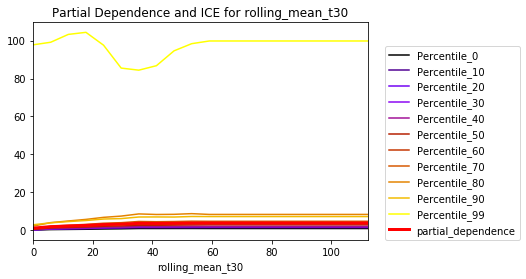

```python
plot_par_dep_ICE('rolling_mean_t30', par_dep_rm30) # plot partial dependence and ICE for rolling_mean_t7
```

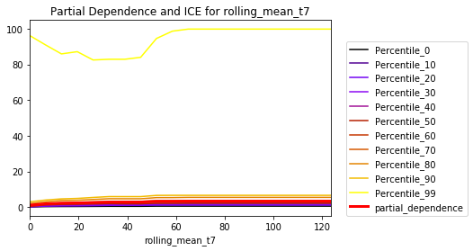

```python
plot_par_dep_ICE('rolling_mean_t7', par_dep_rm7) # plot partial dependence and ICE for rolling_mean_t7
```

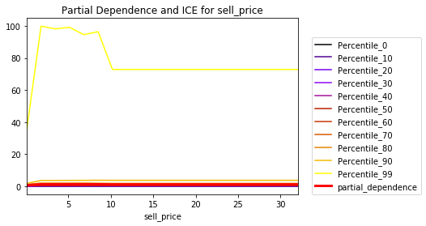

```python
plot_par_dep_ICE('sell_price', par_dep_sell_price) # plot partial dependence and ICE for sell_price
```

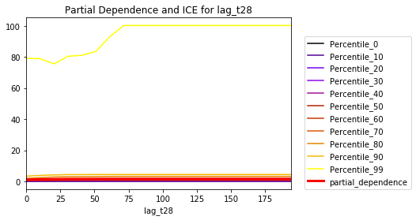

```python
plot_par_dep_ICE('lag_t28', par_dep_lag_t28) # plot partial dependence and ICE for lag_t28
```

In Patrick's notebook example that we have cited at the end of this notebook, the curve of `Percentile_99` is also higher than other curves. But in our case, it is too high to see the behavior of other curves.

The histograms below present the distributions of items regarding `rolling_mean_t30`, `rolling_mean_t7`,`sell_price`, and `lag_t28`. Predictions based on small amounts of training data are likely less dependable. Since we the data distribution for these 4 features are highly right skewedTherefore, the ICE curves at 99th percentile for all 4 features act strange and not in a monotonic progression. The predictions at lower percentiles all behave monotonically and as expected.

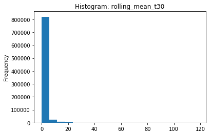

```python
_ = small_val['rolling_mean_t30'].plot(kind='hist', bins=20, title='Histogram: rolling_mean_t30')
```

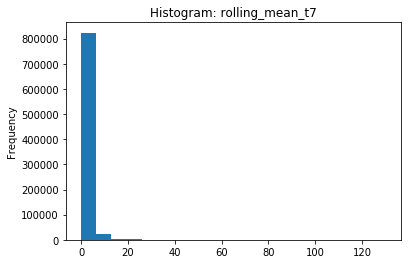

```python
_ = small_val['rolling_mean_t7'].plot(kind='hist', bins=20, title='Histogram: rolling_mean_t7')
```

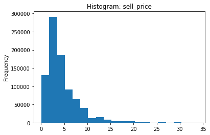

```python
_ = small_val['sell_price'].plot(kind='hist', bins=20, title='Histogram: sell_price')
```

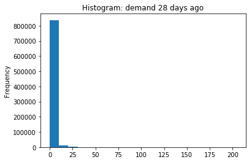

```python
_ = small_val['lag_t28'].plot(kind='hist', bins=20, title='Histogram: demand 28 days ago')
```

## **8. Sensitivity Analysis**

## Preparation for sensitivity analysis

```python
sval_hat.head()
```

|  | id | item_id | dept_id | cat_id | store_id | state_id | date | month | year | event_name_1 | event_type_1 | event_name_2 | event_type_2 | snap_CA | snap_TX | snap_WI | sell_price | lag_t28 | lag_t29 | lag_t30 | rolling_mean_t7 | rolling_std_t7 | rolling_mean_t30 | rolling_mean_t90 | rolling_mean_t180 | rolling_std_t30 | rolling_skew_t30 | rolling_kurt_t30 | price_change_t1 | … |
| --- | --- | --- | --- | --- | --- | --- | --- | --- | --- | --- | --- | --- | --- | --- | --- | --- | --- | --- | --- | --- | --- | --- | --- | --- | --- | --- | --- | --- | --- | --- |
| 28327370 | 14370 | 0.405029 | 0.754883 | 0.616211 | 1.377930 | 1.291992 | 20160425 | 4 | 2016 | 30 | 4 | 2 | 2 | 0 | 0 | 0 | 8.382812 | 1.0 | 1.0 | 1.0 | 1.142578 | 0.689941 | 1.033203 | 0.944336 | 0.772461 | 0.927734 | 0.763184 | 0.018387 | 0.0 | … |
| 28327371 | 14380 | 0.257324 | 0.757812 | 0.619141 | 1.385742 | 1.291992 | 20160425 | 4 | 2016 | 30 | 4 | 2 | 2 | 0 | 0 | 0 | 3.970703 | 1.0 | 1.0 | 1.0 | 0.714355 | 0.488037 | 0.333252 | 0.211060 | 0.377686 | 0.479492 | 0.745117 | -1.553711 | 0.0 | … |
| 28327372 | 14390 | 0.151245 | 0.751465 | 0.621094 | 1.370117 | 1.291992 | 20160425 | 4 | 2016 | 30 | 4 | 2 | 2 | 0 | 0 | 0 | 2.970703 | 0.0 | 0.0 | 1.0 | 0.285645 | 0.488037 | 0.500000 | 0.344482 | 0.633301 | 1.166992 | 3.904297 | 17.734375 | 0.0 | … |
| 28327373 | 14400 | 2.111328 | 0.743652 | 0.617676 | 1.384766 | 1.295898 | 20160425 | 4 | 2016 | 30 | 4 | 2 | 2 | 0 | 0 | 0 | 4.640625 | 0.0 | 6.0 | 6.0 | 3.000000 | 2.708984 | 1.966797 | 2.033203 | 1.900391 | 2.076172 | 0.791016 | -0.692871 | 0.0 | … |
| 28327374 | 14410 | 0.740723 | 0.759766 | 0.611816 | 1.386719 | 1.308594 | 20160425 | 4 | 2016 | 30 | 4 | 2 | 2 | 0 | 0 | 0 | 2.880859 | 1.0 | 0.0 | 0.0 | 0.714355 | 1.112305 | 1.099609 | 0.966797 | 1.171875 | 0.959473 | 0.541992 | -0.524414 | 0.0 | … |

```python
# find percentiles of predictions
percentile_dict = get_percentile_dict('pred_demand', 'id', sval_hat)
percentile_dict
```

```
{0: 20903,
 99: 7022,
 10: 7917,
 20: 29920,
 30: 17195,
 40: 24829,
 50: 5303,
 60: 5021,
 70: 15866,
 80: 13447,
 90: 13041}
```

## test of prediction range

In order to test whether the prediction range make sense, we will check whether `pred_demand` values are all positive and compare `pred_demand` with historical data `rolling_mean_t7`, to see if the value is reasonable.

```python
# Display validation data prediction range
print('Lowest prediction')
print(sval_hat[sval_hat['id'] == int(percentile_dict[0])][['id','pred_demand','rolling_mean_t7']])
print()
print('Highest prediction')
print(sval_hat[sval_hat['id'] == int(percentile_dict[99])][['id','pred_demand','rolling_mean_t7']])
```

```
Lowest prediction
             id  pred_demand  rolling_mean_t7
28337170  20903     0.040953         0.000000
28367660  20903     0.040406         0.000000
28398150  20903     0.041344         0.000000
28428640  20903     0.041817         0.000000
28459130  20903     0.040809         0.000000
28489620  20903     0.045135         0.000000
28520110  20903     0.041435         0.000000
28550600  20903     0.039789         0.000000
28581090  20903     0.041192         0.000000
28611580  20903     0.038522         0.000000
28642070  20903     0.035508         0.000000
28672560  20903     0.036672         0.000000
28703050  20903     0.094555         0.142822
```

[output cut: 46 more lines]

The lowest prediction is among the results of prediction demand of item '20903'. There is no big difference between its `rolling_mean_t7` and its demand prediction. Besides, all the predictions are positive. Therefore, the lower bound of model output makes sense.  
The highest prediction is among the results of prediction demand of item '7022'. The demand predictions and `rolling_mean_t7` values for this item have the same trend: both of them are high. Therefore, we think the upper bound of model output is also reasonable.

## Test the effect of changing **sell_price**

```python
# get the max price and min price
print('The maximum price is:', sval_hat['sell_price'].max())
print('The average price is:', sval_hat['sell_price'].min())
```

```
The maximum price is: 33.72
The average price is: 0.1
```

```python
# Have a look at the price of the item with the highest demand prediction
sval_hat[sval_hat['id'] == int(percentile_dict[99])][['id','sell_price']].head()
```

|  | id | sell_price |
| --- | --- | --- |
| 28335782 | 7022 | 1.599609 |
| 28366272 | 7022 | 1.599609 |
| 28396762 | 7022 | 1.599609 |
| 28427252 | 7022 | 1.599609 |
| 28457742 | 7022 | 1.599609 |

### Sensitivity Test for Item `7022`

We're going to test the item with encoded id `7022` by changing its price.

```python
# Assign a higher price and a lower price to this item
old_price = 1.599609
higher_price = 20
lower_price = 0.5
```

See what might happen when price surges due to lack of supply

```python
# Change sell_price to higher_price for item 7022
small_val1 = data[(data['date'] > 20160424) & (data['date'] <= 20160522)]
small_val1['sell_price'].replace({old_price: higher_price}, inplace = True)
```

```python
small_val1.loc[small_val1['id'] == 7022]['sell_price'].head()
```

```
28335782    20.0
28366272    20.0
28396762    20.0
28427252    20.0
28457742    20.0
Name: sell_price, dtype: float16
```

```python
# Refit the model
y_sval1 = small_val1['demand']
del small_val1['demand']
dsval1 = xgb.DMatrix(small_val1, y_sval1)
sval_hat1 = small_val1
sval_hat1['new_pred_demand'] = xgb_tg_encode.predict(dsval1, ntree_limit=xgb_tg_encode.best_ntree_limit)
```

```python
# Have a look at new_pred_demand
new_demand = sval_hat1[sval_hat1['id'] == int(percentile_dict[99])]['new_pred_demand']
new_demand.head()
```

```
28335782    61.752686
28366272    56.039017
28396762    59.275284
28427252    63.059021
28457742    73.369156
Name: new_pred_demand, dtype: float32
```

```python
# Have a look at new_pred_demand
new_demand = sval_hat1[sval_hat1['id'] == int(percentile_dict[99])]['new_pred_demand']
new_demand.head()
```

```python
# combine old pred_demand with new_pred_demand
sval_hat['higher_price_demand'] = new_demand

# Compare old pred_demand with new_pred_demand given the change of price
sval_hat[sval_hat['id'] == int(percentile_dict[99])][['id','pred_demand','higher_price_demand']]
```

|  | id | pred_demand | higher_price_demand |
| --- | --- | --- | --- |
| 28335782 | 7022 | 85.411781 | 61.752686 |
| 28366272 | 7022 | 79.250328 | 56.039017 |
| 28396762 | 7022 | 84.164169 | 59.275284 |
| 28427252 | 7022 | 91.529701 | 63.059021 |
| 28457742 | 7022 | 107.908226 | 73.369156 |
| 28488232 | 7022 | 115.743507 | 78.656021 |
| 28518722 | 7022 | 126.563179 | 94.556015 |
| 28549212 | 7022 | 97.170021 | 74.614159 |
| 28579702 | 7022 | 96.285568 | 72.092934 |
| 28610192 | 7022 | 93.308487 | 69.568306 |
| 28640682 | 7022 | 97.700096 | 73.275558 |
| 28671172 | 7022 | 110.543602 | 79.742661 |
| 28701662 | 7022 | 121.543762 | 89.258156 |
| 28732152 | 7022 | 127.559113 | 96.032738 |
| 28762642 | 7022 | 96.717979 | 73.820625 |
| 28793132 | 7022 | 90.117844 | 67.842918 |
| 28823622 | 7022 | 93.729004 | 70.432709 |
| 28854112 | 7022 | 90.551346 | 67.539185 |
| 28884602 | 7022 | 111.157913 | 81.424782 |
| 28915092 | 7022 | 116.701317 | 85.738464 |
| 28945582 | 7022 | 120.656456 | 90.299538 |
| 28976072 | 7022 | 85.957024 | 63.595673 |
| 29006562 | 7022 | 83.286819 | 60.263107 |
| 29037052 | 7022 | 83.067726 | 59.995052 |
| 29067542 | 7022 | 84.557137 | 60.740101 |
| 29098032 | 7022 | 99.468414 | 70.556305 |
| 29128522 | 7022 | 100.771439 | 71.122948 |
| 29159012 | 7022 | 104.642960 | 75.461578 |

We can see that by increasing the sell price, the `pred_demand` decrease significantly. This result is reasonable. Therefore, when there is a large swing in this essential variable `sell_price`, the model is quite stable.

Then we're going to test what might happen when `sell_price` drops.

```python
# Change sell_price for item 7022
small_val2 = data[(data['date'] > 20160424) & (data['date'] <= 20160522)]
small_val2['sell_price'].replace({old_price: lower_price}, inplace = True)

small_val2.loc[small_val2['id'] == 7022]['sell_price'].head()
```

```
28335782    0.5
28366272    0.5
28396762    0.5
28427252    0.5
28457742    0.5
Name: sell_price, dtype: float16
```

```python
# Refit the model
y_sval2 = small_val2['demand']
del small_val2['demand']
dsval2 = xgb.DMatrix(small_val2, y_sval2)
sval_hat2 = small_val2
sval_hat2['lower_price_demand'] = xgb_tg_encode.predict(dsval2, ntree_limit=xgb_tg_encode.best_ntree_limit)
```

```python
# Have a look at new_pred_demand
new_demand1 = sval_hat2[sval_hat2['id'] == int(percentile_dict[99])]['lower_price_demand']
new_demand1.head()
```

```
28335782    40.157822
28366272    33.893620
28396762    36.584953
28427252    41.205536
28457742    53.493462
Name: lower_price_demand, dtype: float32
```

```python
# combine old pred_demand with new_pred_demand
sval_hat['lower_price_demand'] = new_demand1

# Compare old pred_demand with new_pred_demand given the change of price
sval_hat[sval_hat['id'] == int(percentile_dict[99])][['id','pred_demand','lower_price_demand']]
```

|  | id | pred_demand | lower_price_demand |
| --- | --- | --- | --- |
| 28335782 | 7022 | 85.411781 | 40.157822 |
| 28366272 | 7022 | 79.250328 | 33.893620 |
| 28396762 | 7022 | 84.164169 | 36.584953 |
| 28427252 | 7022 | 91.529701 | 41.205536 |
| 28457742 | 7022 | 107.908226 | 53.493462 |
| 28488232 | 7022 | 115.743507 | 57.183540 |
| 28518722 | 7022 | 126.563179 | 62.605267 |
| 28549212 | 7022 | 97.170021 | 45.805023 |
| 28579702 | 7022 | 96.285568 | 43.576729 |
| 28610192 | 7022 | 93.308487 | 42.619938 |
| 28640682 | 7022 | 97.700096 | 46.602127 |
| 28671172 | 7022 | 110.543602 | 57.617252 |
| 28701662 | 7022 | 121.543762 | 61.772358 |
| 28732152 | 7022 | 127.559113 | 73.590981 |
| 28762642 | 7022 | 96.717979 | 43.814796 |
| 28793132 | 7022 | 90.117844 | 41.972607 |
| 28823622 | 7022 | 93.729004 | 44.241734 |
| 28854112 | 7022 | 90.551346 | 44.868404 |
| 28884602 | 7022 | 111.157913 | 53.764347 |
| 28915092 | 7022 | 116.701317 | 56.151627 |
| 28945582 | 7022 | 120.656456 | 58.200603 |
| 28976072 | 7022 | 85.957024 | 35.902306 |
| 29006562 | 7022 | 83.286819 | 34.376987 |
| 29037052 | 7022 | 83.067726 | 34.286556 |
| 29067542 | 7022 | 84.557137 | 35.137802 |
| 29098032 | 7022 | 99.468414 | 46.833961 |
| 29128522 | 7022 | 100.771439 | 47.256302 |
| 29159012 | 7022 | 104.642960 | 48.940857 |

There is a huge decrease in `pred_demand` given the lower price. It is kind of contrary to our intuition. A potential explanation is that a sales activity is needed when the predicted demand is facing a decrease.

### Sensitivity Test for Item `24829`

```python
# Have a look at the price of the item with the highest demand prediction
sval_hat[sval_hat['id'] == int(percentile_dict[40])][['id','sell_price']].head()
```

|  | id | sell_price |
| --- | --- | --- |
| 28355856 | 24829 | 12.96875 |
| 28386346 | 24829 | 12.96875 |
| 28416836 | 24829 | 12.96875 |
| 28447326 | 24829 | 12.96875 |
| 28477816 | 24829 | 12.96875 |

```python
# Assign a higher price and a lower price to this item
old_price = 12.96875
higher_price = 20
lower_price = 0.5
```

See what might happen when price surges due to lack of supply.

```python
# Change sell_price to higher_price for item 24829
small_val1 = data[(data['date'] > 20160424) & (data['date'] <= 20160522)]
small_val1['sell_price'].replace({old_price: higher_price}, inplace = True)

small_val1.loc[small_val1['id'] == 24829]['sell_price'].head()
```

```
28355856    20.0
28386346    20.0
28416836    20.0
28447326    20.0
28477816    20.0
Name: sell_price, dtype: float16
```

```python
# Refit the model
y_sval1 = small_val1['demand']
del small_val1['demand']
dsval1 = xgb.DMatrix(small_val1, y_sval1)
sval_hat1 = small_val1
sval_hat1['new_pred_demand'] = xgb_tg_encode.predict(dsval1, ntree_limit=xgb_tg_encode.best_ntree_limit)
```

```python
# Have a look at new_pred_demand
new_demand = sval_hat1[sval_hat1['id'] == int(percentile_dict[40])]['new_pred_demand']
new_demand.head()
```

```
28355856    0.244241
28386346    0.308200
28416836    0.331805
28447326    0.301087
28477816    0.335206
Name: new_pred_demand, dtype: float32
```

```python
# combine old pred_demand with new_pred_demand
sval_hat['higher_price_demand'] = new_demand
```

```python
# Compare old pred_demand with new_pred_demand given the change of price
sval_hat[sval_hat['id'] == int(percentile_dict[40])][['id','pred_demand','higher_price_demand']]
```

|  | id | pred_demand | higher_price_demand |
| --- | --- | --- | --- |
| 28355856 | 24829 | 0.244241 | 0.244241 |
| 28386346 | 24829 | 0.308200 | 0.308200 |
| 28416836 | 24829 | 0.331805 | 0.331805 |
| 28447326 | 24829 | 0.301087 | 0.301087 |
| 28477816 | 24829 | 0.335206 | 0.335206 |
| 28508306 | 24829 | 0.400471 | 0.400471 |
| 28538796 | 24829 | 0.382236 | 0.382236 |
| 28569286 | 24829 | 0.340403 | 0.340403 |
| 28599776 | 24829 | 0.305452 | 0.305452 |
| 28630266 | 24829 | 0.247043 | 0.247043 |
| 28660756 | 24829 | 0.215002 | 0.215002 |
| 28691246 | 24829 | 0.285090 | 0.285090 |
| 28721736 | 24829 | 0.494927 | 0.494927 |
| 28752226 | 24829 | 0.407558 | 0.407558 |
| 28782716 | 24829 | 0.300360 | 0.300360 |
| 28813206 | 24829 | 0.280441 | 0.280441 |
| 28843696 | 24829 | 0.289470 | 0.289470 |
| 28874186 | 24829 | 0.337183 | 0.337183 |
| 28904676 | 24829 | 0.363555 | 0.363555 |
| 28935166 | 24829 | 0.362651 | 0.362651 |
| 28965656 | 24829 | 0.435973 | 0.435973 |
| 28996146 | 24829 | 0.307243 | 0.307243 |
| 29026636 | 24829 | 0.351304 | 0.351304 |
| 29057126 | 24829 | 0.352969 | 0.352969 |
| 29087616 | 24829 | 0.322055 | 0.322055 |
| 29118106 | 24829 | 0.363413 | 0.363413 |
| 29148596 | 24829 | 0.436529 | 0.436529 |
| 29179086 | 24829 | 0.391035 | 0.391035 |

Since item `24829` has a relative high individual price, the consumer for this item might not be sensitive to price. Therefore, the test out indicates that the rise of price is not likely to have a noticeable impact on its predicted demand, which is consistent with our intuition.

Then we're going to test what might happen when `sell_price` drops.

```python
# Change sell_price for item 24829
small_val2 = data[(data['date'] > 20160424) & (data['date'] <= 20160522)]
small_val2['sell_price'].replace({old_price: lower_price}, inplace = True)

small_val2.loc[small_val2['id'] == 24829]['sell_price'].head()
```

```
28355856    0.5
28386346    0.5
28416836    0.5
28447326    0.5
28477816    0.5
Name: sell_price, dtype: float16
```

```python
# Refit the model
y_sval2 = small_val2['demand']
del small_val2['demand']
dsval2 = xgb.DMatrix(small_val2, y_sval2)
sval_hat2 = small_val2
sval_hat2['lower_price_demand'] = xgb_tg_encode.predict(dsval2, ntree_limit=xgb_tg_encode.best_ntree_limit)
```

```python
# Have a look at new_pred_demand
new_demand1 = sval_hat2[sval_hat2['id'] == int(percentile_dict[40])]['lower_price_demand']
new_demand1.head()
```

```
28355856    0.269790
28386346    0.337067
28416836    0.356752
28447326    0.330132
28477816    0.376511
Name: lower_price_demand, dtype: float32
```

```python
# combine old pred_demand with new_pred_demand
sval_hat['lower_price_demand'] = new_demand1
```

```python
# Compare old pred_demand with new_pred_demand given the change of price
sval_hat[sval_hat['id'] == int(percentile_dict[40])][['id','pred_demand','lower_price_demand']]
```

|  | id | pred_demand | lower_price_demand |
| --- | --- | --- | --- |
| 28355856 | 24829 | 0.244241 | 0.269790 |
| 28386346 | 24829 | 0.308200 | 0.337067 |
| 28416836 | 24829 | 0.331805 | 0.356752 |
| 28447326 | 24829 | 0.301087 | 0.330132 |
| 28477816 | 24829 | 0.335206 | 0.376511 |
| 28508306 | 24829 | 0.400471 | 0.434291 |
| 28538796 | 24829 | 0.382236 | 0.407118 |
| 28569286 | 24829 | 0.340403 | 0.371507 |
| 28599776 | 24829 | 0.305452 | 0.335514 |
| 28630266 | 24829 | 0.247043 | 0.274336 |
| 28660756 | 24829 | 0.215002 | 0.232716 |
| 28691246 | 24829 | 0.285090 | 0.320042 |
| 28721736 | 24829 | 0.494927 | 0.532370 |
| 28752226 | 24829 | 0.407558 | 0.432826 |
| 28782716 | 24829 | 0.300360 | 0.328083 |
| 28813206 | 24829 | 0.280441 | 0.310835 |
| 28843696 | 24829 | 0.289470 | 0.317542 |
| 28874186 | 24829 | 0.337183 | 0.366654 |
| 28904676 | 24829 | 0.363555 | 0.394714 |
| 28935166 | 24829 | 0.362651 | 0.404550 |
| 28965656 | 24829 | 0.435973 | 0.465191 |
| 28996146 | 24829 | 0.307243 | 0.340240 |
| 29026636 | 24829 | 0.351304 | 0.395477 |
| 29057126 | 24829 | 0.352969 | 0.384961 |
| 29087616 | 24829 | 0.322055 | 0.353555 |
| 29118106 | 24829 | 0.363413 | 0.393625 |
| 29148596 | 24829 | 0.436529 | 0.467614 |
| 29179086 | 24829 | 0.391035 | 0.417425 |

When the selling price of this high-valued item `24829` decreases a lot, there is an increase in prediction of demand, which is reasonable.

According to this sensitivity analysis, the xgb model appears stable.

## **Credits**

- Melt and Merge: https://www.kaggle.com/ragnar123/very-fst-model
- Target encoding: https://www.kaggle.com/ogrellier/python-target-encoding-for-categorical-features
- Calculating Shapley value, Partial Dependence and drawing ICE curve: https://nbviewer.jupyter.org/github/jphall663/interpretable_machine_learning_with_python/blob/master/xgboost_pdp_ice.ipynb